[figure not shown]

# Coordination des Centres de Prévention et de Santé de Guyane

# Activité mensuelle des CDPS - Décembre 2021

Cyril Le Borgne

05/01/2022

# 1 EMSPEC - Equipe mobile de santé publique en commune

## 1.1 Présentation

**L’Équipe Mobile de Santé Publique En Commune (EMSPEC)** est rattachée au service des Centres Délocalisés de Prévention et de Soin (CDPS) du Centre Hospitalier de Cayenne (CHC). Ses missions répondent aux besoins importants de santé publique des populations les plus éloignées du soin et de la prévention, résidants dans les communes de l’intérieur de Guyane, en s’appuyant et en complément de l’offre sanitaire assurée par les CDPS.

Trois équipes infirmiers-médiateurs accompagnés d’une équipe de coordination à Cayenne sont présentes sur le terrain à St Georges de l’Oyapock, Grand Santi et Maripasoula dans le but d’ « amélioration de l’état de santé de la population guyanaise » et de « lutte contre les inégalités sociales et territoriales de santé à 10 ans », objectifs 2018-2028 du Plan Régional de Santé.

[figure not shown]

[figure not shown]

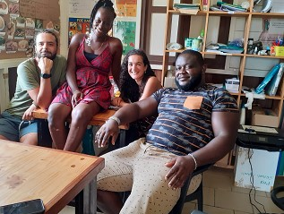

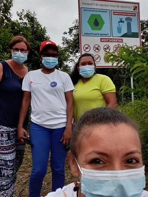

## 1.2 Axes d’intervention

- Identifier et comprendre les besoins des populations
- Accompagner les équipes des CDPS : pré-affectation, accompagner les enseignements postuniversitaires, accompagner les patients dans leur parcours de soins et renseigner les soignants sur les protocoles
- Promotion de la santé : création d’outils, actions et animations en promotion de la santé en population générale et en milieu scolaire
- « Aller-vers » : recherche des perdus de vue, continuité des soins, gestion des épidémies et autres phénomènes
- Coopération transfrontalière Surinam et Brésil : cartographie de l’offre sanitaire, pirogues binationales, coopération hospitalière

## 1.3 Thématiques principales en 2021

- **Projet WASH** avec la Croix Rouge Française : eau, hygiène et assainissement : Créations d’outils de sensibilisation et animations sur : maladies vectorielles, maladies liées à l’eau, stockage, transport et potabilisation de l’eau
- **COVID 19 :** Créations d’outils de sensibilisation et animation sur les gestes barrières, la vaccination
- **Education à la Vie Relationnelle, Affective et Sexuelle** (EVRAS) : Créations d’outils et animations en milieu scolaire
- **Réduction des risques/ Lutte contre les addictions :** Création d’outils et sensibilisation en lien avec l’infirmière coordinatrice RDR des CDPS
- **Autres thématiques** : paludisme, lutte contre les métaux lourds, alimentation, vaccination…

## 1.4 Actions du mois

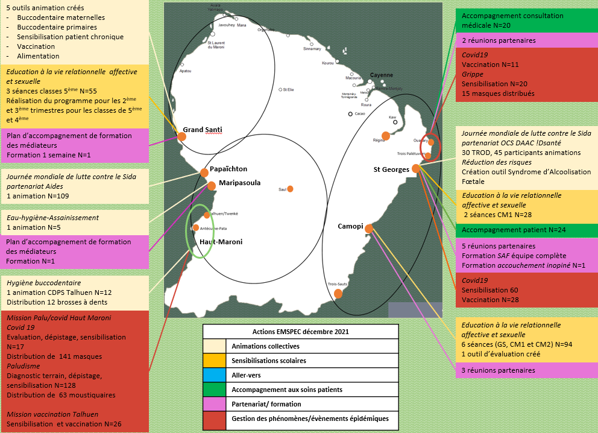

# 2 Nombre de fiches créées dans SISv2

|  | 2021 |  |  |  |  |  |  |  |  |  |  |  | Total |
| --- | --- | --- | --- | --- | --- | --- | --- | --- | --- | --- | --- | --- | --- |
|  | janv. | févr. | mars | avr. | mai | juin | juil. | août | sept. | oct. | nov. | déc. |  |
| Pré-consultation | 7516 | 6171 | 9211 | 8500 | 8476 | 9050 | 7953 | 7178 | 8571 | 8214 | 8026 | 6942 | 95808 |
| Consultation | 5769 | 4791 | 6389 | 5465 | 5341 | 5773 | 4826 | 4678 | 6361 | 6024 | 6317 | 5337 | 67071 |
| Vaccination | 474 | 668 | 615 | 572 | 426 | 490 | 647 | 468 | 594 | 770 | 865 | 814 | 7403 |
| Consultation obstétrique | 346 | 327 | 360 | 339 | 306 | 347 | 286 | 277 | 323 | 305 | 311 | 239 | 3766 |
| Mise en observation | 264 | 192 | 216 | 258 | 258 | 282 | 264 | 250 | 245 | 323 | 291 | 316 | 3159 |
| Echographie | 211 | 126 | 143 | 123 | 184 | 188 | 104 | 116 | 113 | 100 | 138 | 83 | 1629 |
| Accouchement | 7 | 10 | 6 | 9 | 7 | 12 | 11 | 7 | 4 |  | 4 | 1 | 78 |
| Total | 14587 | 12285 | 16940 | 15266 | 14998 | 16142 | 14091 | 12974 | 16211 | 15736 | 15952 | 13732 | 178914 |

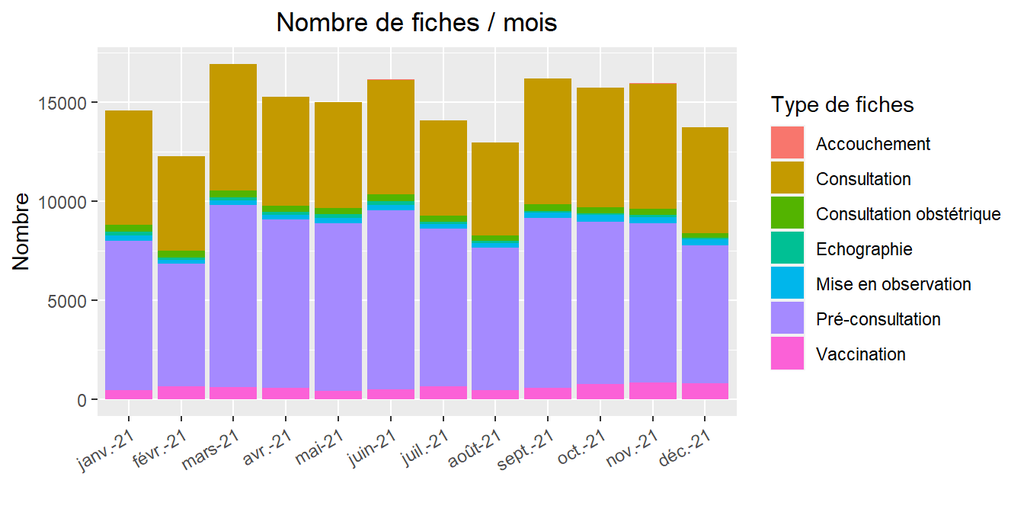

# 3 File active quotienne

Le tableau ci-dessous donne la moyenne du nombre de patients accueillis dans les centres pour chaque jour de la semaine, sur les 12 derniers mois.

|  | 2021 |  |  |  |  |  |  |  |  |  |  |  | Moyenne |
| --- | --- | --- | --- | --- | --- | --- | --- | --- | --- | --- | --- | --- | --- |
|  | janv. | févr. | mars | avr. | mai | juin | juil. | août | sept. | oct. | nov. | déc. |  |
| Lundi | 433 | 359 | 459 | 346 | 369 | 466 | 367 | 355 | 499 | 502 | 398 | 352 | 408 |
| Mardi | 407 | 305 | 401 | 430 | 463 | 435 | 396 | 356 | 468 | 463 | 425 | 385 | 411 |
| Mercredi | 435 | 319 | 421 | 468 | 504 | 517 | 336 | 368 | 409 | 456 | 438 | 357 | 420 |
| Jeudi | 422 | 412 | 424 | 416 | 359 | 362 | 390 | 365 | 447 | 434 | 356 | 349 | 395 |
| Vendredi | 317 | 326 | 361 | 351 | 399 | 408 | 378 | 319 | 431 | 383 | 408 | 285 | 362 |
| Samedi | 73 | 62 | 64 | 64 | 68 | 66 | 72 | 55 | 76 | 73 | 66 | 63 | 67 |
| Dimanche | 54 | 44 | 50 | 52 | 65 | 55 | 56 | 51 | 56 | 60 | 54 | 52 | 54 |

# 4 Consultations de médecine générale

Sont prises en comptes toutes les fiches *Consultation* et *Consultation obstetricale* pour lesquelles le type de consultation renseignée est “**A - Consultation de médecine générale (Examen clinique / consultation médicale)“**

|  | Décembre |  |  |  |  |  |  |  |  |  |  |  |  |  |  |  |  |  |
| --- | --- | --- | --- | --- | --- | --- | --- | --- | --- | --- | --- | --- | --- | --- | --- | --- | --- | --- |
|  | Maripasoula | Saint Georges | Grand Santi | Apatou | Papaichton | Talhuen | Antecum Pata | Cacao | Regina | Saul | Camopi | Trois Sauts | Kaw | Iracoubo | Javouhey | Awala | Zones hors CDPS | Total |
| Médecine générale | 827 | 819 | 926 | 522 | 407 | 170 | 35 | 85 | 32 |  | 370 | 142 | 5 |  | 248 | 137 |  | 4726 |

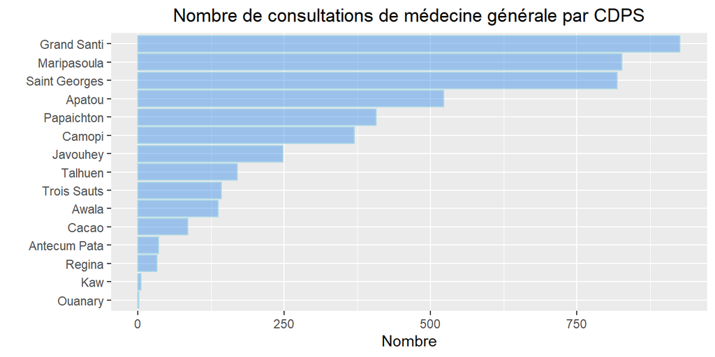

# 5 Consultations sages-femmes

|  | Décembre |  |  |  |  |  |  |  |  |  |  |  |  |  |  |  |  |  |
| --- | --- | --- | --- | --- | --- | --- | --- | --- | --- | --- | --- | --- | --- | --- | --- | --- | --- | --- |
|  | Maripasoula | Saint Georges | Grand Santi | Apatou | Papaichton | Talhuen | Antecum Pata | Cacao | Regina | Saul | Camopi | Trois Sauts | Kaw | Iracoubo | Javouhey | Awala | Zones hors CDPS | Total |
| Consultation | 66 | 76 | 74 | 2 | 13 | 1 | 1 | 3 | 5 |  | 1 |  |  |  |  |  |  | 242 |
| Consultation obstétrique | 56 | 46 | 80 |  | 20 |  |  | 1 |  |  | 6 |  |  |  |  |  |  | 209 |
| Echographie | 38 | 7 | 19 |  | 2 |  |  |  |  |  |  |  |  |  |  |  |  | 66 |
| Total | 160 | 129 | 173 | 2 | 35 | 1 | 1 | 4 | 5 |  | 7 |  |  |  |  |  |  | 517 |

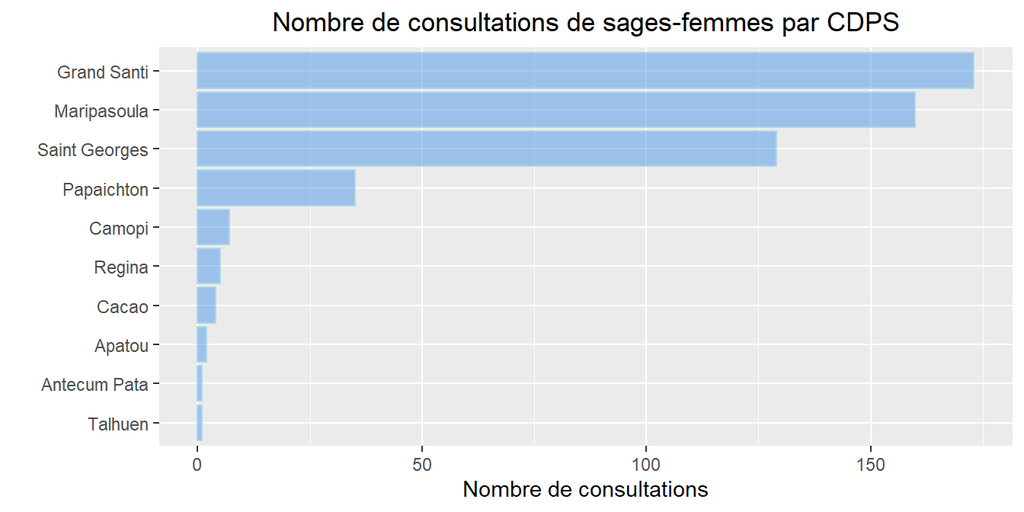

# 6 Accouchements

Les accouchements enregistrés dans SISv2 concernent à la fois ceux réalisés dans des **établissements de santé** et ceux réalisés **en dehors**.

Le tableau ci-dessous fournit le détail des lieux d’accouchement par CDPS pour Décembre.

|  | Décembre |  |  |  |  |  |  |  |  |  |  |  |  |  |  |  |  |  |
| --- | --- | --- | --- | --- | --- | --- | --- | --- | --- | --- | --- | --- | --- | --- | --- | --- | --- | --- |
|  | Maripasoula | Saint Georges | Grand Santi | Apatou | Papaichton | Talhuen | Antecum Pata | Cacao | Regina | Saul | Camopi | Trois Sauts | Kaw | Iracoubo | Javouhey | Awala | Zones hors CDPS | Total |
| Centre délocalisé de prévention et de soin |  | 1 |  |  |  |  |  |  |  |  |  |  |  |  |  |  |  | 1 |
| Total |  | 1 |  |  |  |  |  |  |  |  |  |  |  |  |  |  |  | 1 |

# 7 Consultation / Préconsultations par IDE et AS

|  | Décembre |  |  |  |  |  |  |  |  |  |  |  |  |  |  |  |  |  |
| --- | --- | --- | --- | --- | --- | --- | --- | --- | --- | --- | --- | --- | --- | --- | --- | --- | --- | --- |
|  | Maripasoula | Saint Georges | Grand Santi | Apatou | Papaichton | Talhuen | Antecum Pata | Cacao | Regina | Saul | Camopi | Trois Sauts | Kaw | Iracoubo | Javouhey | Awala | Zones hors CDPS | Total |
| Pré-consultation | 1454 | 750 | 1541 | 743 | 649 | 171 | 162 | 285 | 10 | 42 | 202 | 274 | 7 | 39 | 373 | 239 | 1 | 6942 |
| Consult. paramédicale par IDE ou AS | 4 |  |  |  |  |  |  | 45 | 3 |  |  | 72 |  |  |  |  |  | 124 |
| Addictologie par IDE |  |  |  |  |  |  |  |  | 1 |  |  |  |  |  |  |  |  | 1 |
| Total | 1458 | 750 | 1541 | 743 | 649 | 171 | 162 | 330 | 14 | 42 | 202 | 346 | 7 | 39 | 373 | 239 | 1 | 7067 |

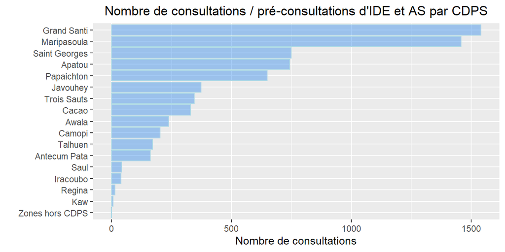

# 8 Consultations spécialisées

|  | Décembre |  |  |  |  |  |  |  |  |  |  |  |  |  |  |  |  |  |
| --- | --- | --- | --- | --- | --- | --- | --- | --- | --- | --- | --- | --- | --- | --- | --- | --- | --- | --- |
|  | Maripasoula | Saint Georges | Grand Santi | Apatou | Papaichton | Talhuen | Antecum Pata | Cacao | Regina | Saul | Camopi | Trois Sauts | Kaw | Iracoubo | Javouhey | Awala | Zones hors CDPS | Total |
| Spécialiste en Pédiatrie | 24 |  |  |  | 14 |  |  |  |  |  | 26 |  |  |  |  |  |  | 64 |
| Gynécologie par un(e) gynécologue | 11 | 24 |  |  |  |  |  |  |  |  |  |  | 1 |  |  |  |  | 36 |
| Spécialiste en Dermatologie |  |  | 9 |  |  |  |  |  |  |  |  |  |  |  | 8 | 11 |  | 28 |
| Spécialiste en Infectiologie | 14 |  |  |  | 10 |  |  |  |  |  |  |  |  |  |  |  | 1 | 25 |
| Psychiatrie (psychiatre ou autre) |  |  | 6 |  |  |  |  |  |  |  |  |  |  |  |  |  |  | 6 |
| Total | 49 | 24 | 15 |  | 24 |  |  |  |  |  | 26 |  | 1 |  | 8 | 11 | 1 | 159 |

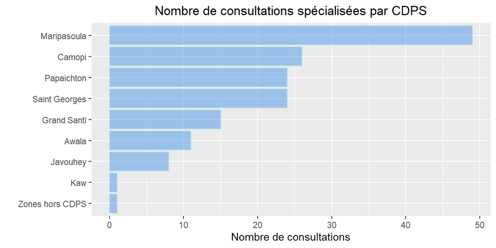

# 9 Mises en observation

|  | Décembre |  |  |  |  |  |  |  |  |  |  |  |  |  |  |  |  |  |
| --- | --- | --- | --- | --- | --- | --- | --- | --- | --- | --- | --- | --- | --- | --- | --- | --- | --- | --- |
|  | Maripasoula | Saint Georges | Grand Santi | Apatou | Papaichton | Talhuen | Antecum Pata | Cacao | Regina | Saul | Camopi | Trois Sauts | Kaw | Iracoubo | Javouhey | Awala | Zones hors CDPS | Total |
| Mise en observation | 64 | 108 | 46 | 41 | 35 | 3 | 2 | 2 |  |  | 8 | 4 |  |  | 1 | 2 |  | 316 |

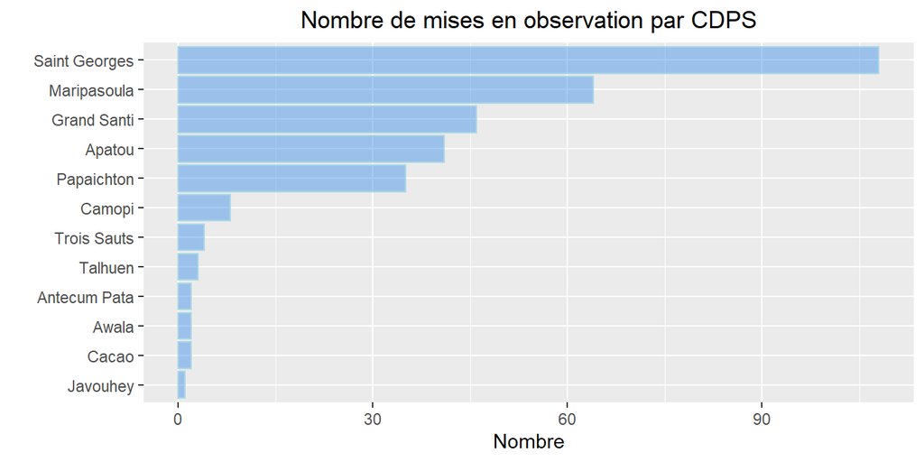

# 10 Transferts urgents

|  | Décembre |  |  |  |  |  |  |  |  |  |  |  |  |  |  |  |  |  |
| --- | --- | --- | --- | --- | --- | --- | --- | --- | --- | --- | --- | --- | --- | --- | --- | --- | --- | --- |
|  | Maripasoula | Saint Georges | Grand Santi | Apatou | Papaichton | Talhuen | Antecum Pata | Cacao | Regina | Saul | Camopi | Trois Sauts | Kaw | Iracoubo | Javouhey | Awala | Zones hors CDPS | Total |
| Hélicoptère | 7 | 6 | 7 |  | 11 |  | 1 | 1 |  |  | 1 |  |  |  |  |  |  | 34 |
| Route | 1 | 19 |  | 8 |  |  |  | 1 |  |  |  |  |  |  |  |  |  | 29 |
| Avion | 1 | 1 | 3 | 1 | 2 |  |  |  |  |  |  |  |  |  |  |  |  | 8 |
| Pirogue |  |  | 4 |  |  |  |  |  |  |  |  |  |  |  |  |  |  | 4 |
| Total | 9 | 26 | 14 | 9 | 13 |  | 1 | 2 |  |  | 1 |  |  |  |  |  |  | 75 |

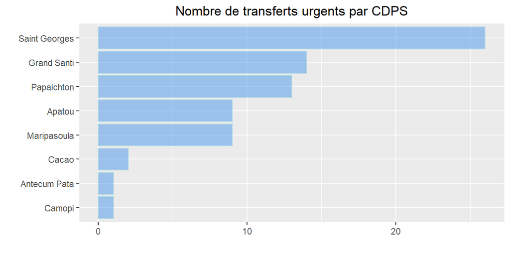

# 11 Décès

## 11.1 Par CDPS

Aucun décès sur la période

## 11.2 Par mois

|  | 2021 |  |  |  |  |  |  |  |  |  |  |  | Total |
| --- | --- | --- | --- | --- | --- | --- | --- | --- | --- | --- | --- | --- | --- |
|  | janv. | févr. | mars | avr. | mai | juin | juil. | août | sept. | oct. | nov. | déc. |  |
| Constat de décès à l''extérieur du CDPS | 1 | 1 |  |  | 1 | 2 | 2 |  |  | 2 | 4 |  | 13 |
| NA | 1 | 2 |  | 2 |  | 1 |  | 2 | 1 |  |  |  | 9 |
| A domicile ou hors CDPS (hors mission) | 1 |  |  |  |  | 1 |  | 1 |  |  |  |  | 3 |
| Médecine générale |  |  |  |  |  | 1 | 1 |  | 1 |  |  |  | 3 |
| Consult. paramédicale par IDE ou AS |  |  |  | 1 |  |  | 1 |  |  |  |  |  | 2 |
| Consultation par SF (hors Gynécologie) |  |  |  |  |  |  | 1 |  | 1 |  |  |  | 2 |
| Constat de décès à l''intérieur du CDPS |  |  |  |  |  |  |  |  |  | 1 |  |  | 1 |
| Décès sans constatation de décès | 1 |  |  |  |  |  |  |  |  |  |  |  | 1 |
| Total | 4 | 3 |  | 3 | 1 | 5 | 5 | 3 | 3 | 3 | 4 |  | 34 |

# 12 Famille de diagnostics

## 12.1 Par CDPS

|  | Décembre |  |  |  |  |  |  |  |  |  |  |  |  |  |  |  |  |  |
| --- | --- | --- | --- | --- | --- | --- | --- | --- | --- | --- | --- | --- | --- | --- | --- | --- | --- | --- |
|  | Maripasoula | Saint Georges | Grand Santi | Apatou | Papaichton | Talhuen | Antecum Pata | Cacao | Regina | Saul | Camopi | Trois Sauts | Kaw | Iracoubo | Javouhey | Awala | Zones hors CDPS | Total |
| EXAMENS GENERAUX | 154 | 154 | 153 | 133 | 77 | 12 | 1 | 32 | 13 |  | 81 | 29 | 2 |  | 64 | 41 |  | 947 |
| MALADIES DE L'APPAREIL RESPIRATOIRES | 63 | 166 | 167 | 106 | 48 | 26 | 4 | 48 | 3 |  | 107 | 74 | 1 |  | 21 | 18 |  | 852 |
| SYMPTOMES, SYNDROME ET ETATS DE MORBIDITES MAL DEFINIS | 175 | 201 | 140 | 71 | 63 | 30 | 4 | 10 | 6 |  | 32 | 14 |  |  | 43 | 28 |  | 817 |
| OBSTETRIQUE | 128 | 146 | 186 | 26 | 52 | 21 |  | 12 | 14 |  | 40 | 15 | 1 |  | 1 | 1 |  | 643 |
| MALADIES INFECTIEUSES ET PARASITAIRES | 109 | 79 | 66 | 39 | 52 | 20 | 7 | 7 | 1 |  | 42 | 28 | 1 |  | 16 | 9 | 1 | 477 |
| LESIONS TRAUMATIQUES EMPOISONNEMENT ET AUTRES CONSEQUENCES DE CAUSES EXTERNE | 79 | 68 | 51 | 37 | 24 | 18 | 1 | 1 | 3 |  | 31 | 8 |  |  | 5 | 8 |  | 334 |
| RHUMATOLOGIE | 65 | 38 | 59 | 30 | 34 | 11 | 7 | 6 | 1 |  | 14 | 8 |  |  | 24 | 5 |  | 302 |
| MALADIES DE L'APPAREIL CARDIO-VASCULAIRE | 55 | 33 | 111 | 20 | 42 | 6 | 1 | 3 |  |  | 9 | 3 |  |  | 11 | 6 |  | 300 |
| DERMATOLOGIE | 45 | 18 | 29 | 12 | 27 | 11 | 2 | 5 | 2 |  | 13 | 12 |  |  | 28 | 21 |  | 225 |
| MALADIES ENDOCRINO-METABOLIQUE | 28 | 47 | 24 | 12 | 11 | 7 | 5 | 6 | 4 |  | 3 | 1 | 1 |  | 5 | 2 |  | 156 |
| MALADIES DE L'APPAREIL DIGESTIF | 30 | 18 | 23 | 14 | 13 | 8 | 3 | 3 |  |  | 7 | 7 |  |  | 5 | 1 |  | 132 |
| ORL | 21 | 24 | 25 | 17 | 9 | 4 | 1 | 1 |  |  | 4 | 5 |  |  | 9 | 4 |  | 124 |
| NEPHROLOGIE/UROLOGIE | 24 | 36 | 14 | 9 | 16 | 4 |  | 4 |  |  | 5 | 3 |  |  | 5 |  |  | 120 |
| NEUROLOGIE | 20 | 19 | 36 | 12 | 6 |  |  |  |  |  | 3 |  |  |  | 10 |  |  | 106 |
| GYNECOLOGIE | 20 | 16 | 10 | 11 | 10 |  |  |  |  |  | 1 | 1 |  |  | 3 | 2 |  | 74 |
| OPHTALMOLOGIE | 20 | 3 | 9 | 9 | 12 | 8 | 1 | 1 |  |  | 1 | 1 |  |  | 4 | 2 |  | 71 |
| TROUBLES MENTAUX ET DU COMPORTEMENT | 14 | 17 | 11 | 10 | 4 | 1 |  | 2 | 1 |  | 6 | 2 |  |  |  |  |  | 68 |
| STOMATOLOGIES | 11 |  | 17 | 6 | 5 | 2 |  |  | 1 |  | 8 | 4 |  |  |  |  |  | 54 |
| MALADIES DU SANG ET ORGANES HEMATOPÏETIQUE | 8 | 3 | 8 | 7 | 5 | 1 |  |  |  |  | 2 |  |  |  | 4 |  |  | 38 |
| CANCEROLOGIE | 3 | 8 | 12 |  | 3 |  |  |  |  |  | 1 |  |  |  |  | 2 |  | 29 |
| MALFORMATIONS CONGENITALES | 5 | 1 | 1 |  | 4 |  |  |  |  |  | 2 |  |  |  |  |  |  | 13 |
| MALADIES DU NOUVEAU NE ET DU NOURISSON | 1 | 1 | 2 |  | 3 |  | 1 |  |  |  |  | 2 |  |  |  |  |  | 10 |
| Total | 1078 | 1096 | 1154 | 581 | 520 | 190 | 38 | 141 | 49 |  | 412 | 217 | 6 |  | 258 | 150 | 1 | 5892 |

## 12.2 Par mois

|  | 2021 |  |  |  |  |  |  |  |  |  |  |  | Total |
| --- | --- | --- | --- | --- | --- | --- | --- | --- | --- | --- | --- | --- | --- |
|  | janv. | févr. | mars | avr. | mai | juin | juil. | août | sept. | oct. | nov. | déc. |  |
| EXAMENS GENERAUX | 942 | 974 | 1240 | 1024 | 1012 | 1559 | 1001 | 1007 | 1208 | 881 | 996 | 947 | 12791 |
| MALADIES DE L'APPAREIL RESPIRATOIRES | 848 | 549 | 738 | 682 | 819 | 579 | 626 | 412 | 1092 | 1146 | 787 | 852 | 9130 |
| SYMPTOMES, SYNDROME ET ETATS DE MORBIDITES MAL DEFINIS | 740 | 617 | 832 | 715 | 645 | 779 | 661 | 624 | 801 | 871 | 888 | 817 | 8990 |
| OBSTETRIQUE | 785 | 681 | 797 | 735 | 689 | 702 | 693 | 642 | 723 | 707 | 808 | 643 | 8605 |
| MALADIES INFECTIEUSES ET PARASITAIRES | 588 | 566 | 700 | 562 | 531 | 544 | 528 | 506 | 544 | 582 | 629 | 477 | 6757 |
| LESIONS TRAUMATIQUES EMPOISONNEMENT ET AUTRES CONSEQUENCES DE CAUSES EXTERNE | 375 | 310 | 383 | 371 | 356 | 339 | 359 | 352 | 402 | 407 | 390 | 334 | 4378 |
| RHUMATOLOGIE | 342 | 291 | 407 | 363 | 301 | 323 | 247 | 252 | 348 | 298 | 373 | 302 | 3847 |
| MALADIES DE L'APPAREIL CARDIO-VASCULAIRE | 283 | 229 | 307 | 325 | 287 | 205 | 220 | 265 | 330 | 298 | 353 | 300 | 3402 |
| DERMATOLOGIE | 272 | 231 | 329 | 273 | 240 | 249 | 205 | 233 | 321 | 257 | 326 | 225 | 3161 |
| MALADIES ENDOCRINO-METABOLIQUE | 173 | 136 | 186 | 189 | 175 | 186 | 155 | 184 | 178 | 195 | 225 | 156 | 2138 |
| MALADIES DE L'APPAREIL DIGESTIF | 149 | 136 | 161 | 148 | 153 | 178 | 103 | 117 | 176 | 164 | 188 | 132 | 1805 |
| NEPHROLOGIE/UROLOGIE | 106 | 97 | 110 | 106 | 109 | 143 | 90 | 117 | 131 | 139 | 175 | 120 | 1443 |
| NEUROLOGIE | 119 | 102 | 159 | 105 | 116 | 115 | 94 | 97 | 132 | 149 | 137 | 106 | 1431 |
| ORL | 132 | 77 | 137 | 100 | 96 | 116 | 76 | 82 | 149 | 159 | 140 | 124 | 1388 |
| GYNECOLOGIE | 91 | 81 | 116 | 91 | 92 | 106 | 89 | 91 | 89 | 87 | 138 | 74 | 1145 |
| OPHTALMOLOGIE | 211 | 55 | 101 | 54 | 45 | 73 | 43 | 43 | 93 | 92 | 116 | 71 | 997 |
| TROUBLES MENTAUX ET DU COMPORTEMENT | 53 | 47 | 66 | 77 | 87 | 55 | 51 | 58 | 70 | 64 | 90 | 68 | 786 |
| STOMATOLOGIES | 66 | 58 | 92 | 62 | 75 | 68 | 50 | 48 | 59 | 58 | 56 | 54 | 746 |
| MALADIES DU SANG ET ORGANES HEMATOPÏETIQUE | 55 | 39 | 58 | 51 | 53 | 47 | 47 | 33 | 42 | 60 | 77 | 38 | 600 |
| CANCEROLOGIE | 12 | 25 | 29 | 13 | 10 | 23 | 14 | 14 | 18 | 17 | 18 | 29 | 222 |
| MALFORMATIONS CONGENITALES | 23 | 9 | 13 | 14 | 8 | 2 | 16 | 4 | 14 | 9 | 4 | 13 | 129 |
| MALADIES DU NOUVEAU NE ET DU NOURISSON | 15 | 7 | 10 | 8 | 12 | 3 | 14 | 9 | 8 | 8 | 6 | 10 | 110 |
| DECES | 3 | 3 |  | 3 | 1 | 5 | 5 | 3 | 4 | 4 | 3 |  | 34 |
| Total | 6383 | 5320 | 6971 | 6071 | 5912 | 6399 | 5387 | 5193 | 6932 | 6652 | 6923 | 5892 | 74035 |

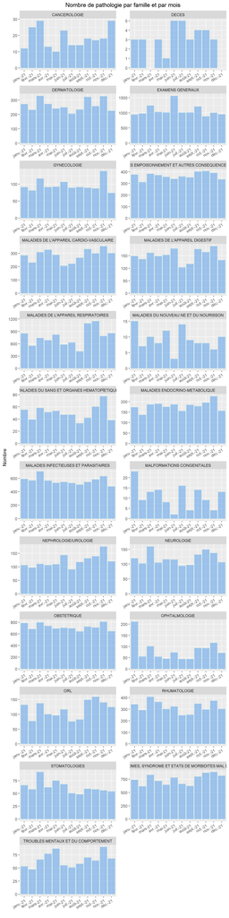

# 13 Actes infirmiers

|  |  | déc. |  |  |  |  |  |  |  |  |  |  |  |  |  |  |  |  |  | Total |
| --- | --- | --- | --- | --- | --- | --- | --- | --- | --- | --- | --- | --- | --- | --- | --- | --- | --- | --- | --- | --- |
|  |  | Maripasoula | Saint Georges | Grand Santi | Apatou | Papaichton | Talhuen | Antecum Pata | Cacao | Regina | Saul | Camopi | Trois Sauts | Kaw | Iracoubo | Javouhey | Awala | Zones hors CDPS | Total |  |
| Accueil - consultation |  | 1395 | 483 | 1521 | 657 | 475 | 156 | 113 | 81 | 4 | 64 | 181 | 307 | 5 | 23 | 300 | 189 |  | 5954 | 5954 |
|  | Examen clinique | 57 | 10 | 12 | 6 | 8 | 1 | 33 | 3 | 1 | 24 |  | 60 |  |  | 2 | 1 |  | 218 | 218 |
|  | Prise des constantes(contrôle TA T° poids) | 1269 | 462 | 710 | 628 | 400 | 142 | 79 | 78 | 3 | 40 | 178 | 246 | 5 | 23 | 286 | 188 |  | 4737 | 4737 |
|  | Traduction | 69 | 11 | 799 | 23 | 67 | 13 | 1 |  |  |  | 3 | 1 |  |  | 12 |  |  | 999 | 999 |
| Administratif |  | 1219 | 312 | 677 | 43 | 350 | 165 | 160 | 9 | 1 | 40 | 117 | 252 |  | 39 | 356 | 22 |  | 3762 | 3762 |
|  | Autres actes administratifs | 1192 | 302 | 646 | 36 | 336 | 165 | 159 | 7 |  | 40 | 117 | 251 |  | 39 | 352 | 22 |  | 3664 | 3664 |
|  | Menage des chambres et/ou salles (>=30 minutes) | 12 | 8 | 20 |  | 7 |  |  |  |  |  |  |  |  |  | 1 |  |  | 48 | 48 |
|  | Organisation/préparation départ (pirogue ou avion ou autre) | 4 | 1 | 4 | 3 |  |  |  |  |  |  |  |  |  |  |  |  |  | 12 | 12 |
|  | Papiers transferts (EVASAN) | 11 | 1 | 7 | 4 | 7 |  | 1 | 2 | 1 |  |  | 1 |  |  | 3 |  |  | 38 | 38 |
| Examen de laboratoire (sous supervision du médecin) |  | 64 | 21 | 54 |  | 21 |  |  |  |  |  | 2 |  |  |  |  |  |  | 162 | 162 |
|  | Analyse de biologie délocalisée par Horiba | 12 | 6 | 12 |  | 1 |  |  |  |  |  |  |  |  |  |  |  |  | 31 | 31 |
|  | Analyse de biologie délocalisée par ISTAT (compter 1 par cartouche) | 41 | 9 | 34 |  | 3 |  |  |  |  |  | 1 |  |  |  |  |  |  | 88 | 88 |
|  | Autre type d''examen de laboratoire | 11 | 6 | 7 |  | 17 |  |  |  |  |  |  |  |  |  |  |  |  | 41 | 41 |
|  | Lecture goutte épaisse - frottis |  |  | 1 |  |  |  |  |  |  |  | 1 |  |  |  |  |  |  | 2 | 2 |
| Injection-Perfusion |  | 199 | 62 | 286 | 104 | 110 | 5 | 39 | 69 |  |  | 7 | 61 |  | 5 | 7 | 15 |  | 969 | 969 |
|  | Injection Intra dermique pour vaccination | 1 |  | 2 |  |  |  |  |  |  |  |  |  |  |  | 1 |  |  | 4 | 4 |
|  | Injection intramsuculaire pour vaccination | 19 | 4 | 171 | 60 | 1 |  | 4 | 64 |  |  | 2 | 42 |  |  | 2 |  |  | 369 | 369 |
|  | Injection sous cutanée pour vaccination |  | 8 | 20 |  |  |  |  | 3 |  |  | 3 |  |  |  | 4 |  |  | 38 | 38 |
|  | Intradermique |  | 1 |  | 1 | 1 |  |  |  |  |  |  |  |  |  |  |  |  | 3 | 3 |
|  | Intramusculaire (IM) | 7 | 7 | 39 | 8 | 8 | 2 |  | 1 |  |  |  |  |  | 3 |  | 15 |  | 90 | 90 |
|  | Intraveineuse (IV) | 83 | 14 | 18 | 15 | 76 |  | 25 |  |  |  | 1 | 11 |  |  |  |  |  | 243 | 243 |
|  | Préparation/pose de perfusion/surveillance < 8 heures | 56 | 9 | 19 | 19 | 12 | 2 | 5 | 1 |  |  | 1 | 4 |  |  |  |  |  | 128 | 128 |
|  | Préparation/pose de perfusion/surveillance > 8 heures | 31 | 12 | 14 |  | 8 | 1 | 1 |  |  |  |  |  |  |  |  |  |  | 67 | 67 |
|  | Sous-cutanée (S/C) | 2 | 7 | 3 | 1 | 4 |  | 4 |  |  |  |  | 4 |  | 2 |  |  |  | 27 | 27 |
| Intervention sur réquisition |  | 1 | 3 |  | 1 | 1 |  |  |  |  |  |  |  |  |  |  |  |  | 6 | 6 |
|  | Intervention sur réquisition <15 minutes |  | 2 |  |  |  |  |  |  |  |  |  |  |  |  |  |  |  | 2 | 2 |
|  | Intervention sur réquisition >30minutes |  |  |  |  | 1 |  |  |  |  |  |  |  |  |  |  |  |  | 1 | 1 |
|  | Intervention sur réquisition 15 à 30 minutes | 1 | 1 |  | 1 |  |  |  |  |  |  |  |  |  |  |  |  |  | 3 | 3 |
| Intervention urgente à l''extérieur du CDPS |  | 69 | 37 | 105 |  | 2 | 1 | 2 |  | 1 |  | 24 |  |  |  | 1 |  |  | 242 | 242 |

[output cut: 54 more lines]

# 14 COVID

## 14.1 Nombre de consultations par CDPS

|  | Décembre |  |  |  |  |  |  |  |  |  |  |  |  |  |  |  |  |  |
| --- | --- | --- | --- | --- | --- | --- | --- | --- | --- | --- | --- | --- | --- | --- | --- | --- | --- | --- |
|  | Maripasoula | Saint Georges | Grand Santi | Apatou | Papaichton | Talhuen | Antecum Pata | Cacao | Regina | Saul | Camopi | Trois Sauts | Kaw | Iracoubo | Javouhey | Awala | Zones hors CDPS | Total |
| Résultat positif | 6 | 10 | 8 | 2 | 3 |  | 1 | 38 | 2 |  |  | 7 |  |  | 1 | 1 |  | 79 |
| Résultat négatif |  |  | 48 | 1 |  |  |  |  | 1 |  |  |  |  |  |  | 1 |  | 51 |
| En attente de résultat |  |  | 1 |  |  |  |  |  |  |  |  |  |  |  |  |  |  | 1 |
| Patient non testé |  |  | 1 |  |  |  |  |  |  |  |  |  |  |  |  |  |  | 1 |
| Total | 6 | 10 | 58 | 3 | 3 |  | 1 | 38 | 3 |  |  | 7 |  |  | 1 | 2 |  | 132 |

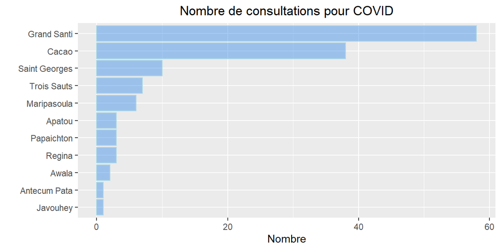

## 14.2 Nombre de patients par mois

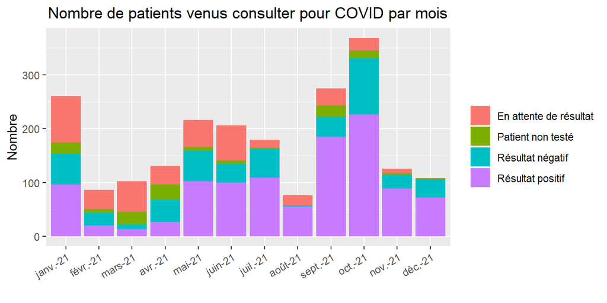

## 14.3 Mise en observation pour COVID

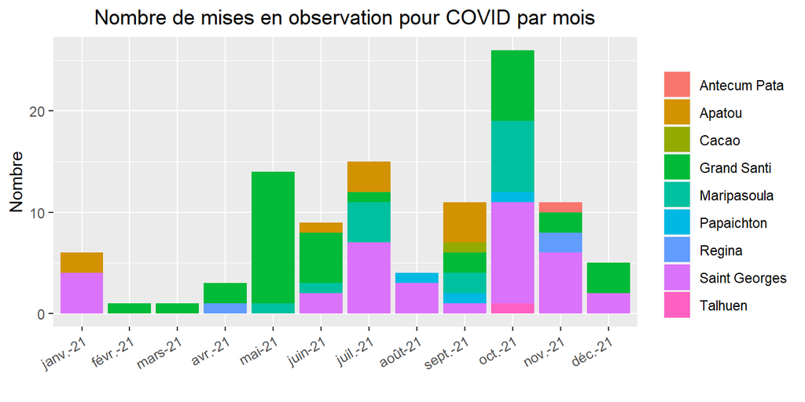

# 15 Lésions auto-infligées

|  | Décembre |  |  |  |  |  |  |  |  |  |  |  |  |  |  |  |  |  |
| --- | --- | --- | --- | --- | --- | --- | --- | --- | --- | --- | --- | --- | --- | --- | --- | --- | --- | --- |
|  | Maripasoula | Saint Georges | Grand Santi | Apatou | Papaichton | Talhuen | Antecum Pata | Cacao | Regina | Saul | Camopi | Trois Sauts | Kaw | Iracoubo | Javouhey | Awala | Zones hors CDPS | Total |
| Lésion auto-infligée par pendaison- strangulation et suffocation (suicide ou tentative) |  |  |  |  |  | 1 |  |  |  |  | 1 |  |  |  |  |  |  | 2 |
| Auto-intoxication par d'autres substances pharmacologiques agissant sur le système nerveux autonome et exposition à ces produits (suicide ou tentative) | 1 |  |  |  |  |  |  |  |  |  |  |  |  |  |  |  |  | 1 |
| Auto-intoxication par des medicaments psychotropes (anti-épileptiques/sédatifs/hypnotiques/antiparkinsoniens et psychotropes....) (suicide ou tentative) | 1 |  |  |  |  |  |  |  |  |  |  |  |  |  |  |  |  | 1 |
| Auto-intoxication par des pesticides et exposition à ces produits (suicide ou tentative) | 1 |  |  |  |  |  |  |  |  |  |  |  |  |  |  |  |  | 1 |
| Total | 3 |  |  |  |  | 1 |  |  |  |  | 1 |  |  |  |  |  |  | 5 |

## 15.1 Sur les 12 derniers mois

### 15.1.1 par type

|  | 2021 |  |  |  |  |  |  |  |  |  |  |  | Total |
| --- | --- | --- | --- | --- | --- | --- | --- | --- | --- | --- | --- | --- | --- |
|  | janv. | févr. | mars | avr. | mai | juin | juil. | août | sept. | oct. | nov. | déc. |  |
| Auto-intoxication par des produits chimiques et substances novices (suicide ou tentative) | 3 |  |  | 2 |  | 1 | 1 |  |  | 1 | 2 |  | 10 |
| Lésion auto-infligée par pendaison- strangulation et suffocation (suicide ou tentative) | 2 |  |  | 2 |  | 2 |  | 1 |  |  | 1 | 2 | 10 |
| Auto-intoxication par d'autres substances pharmacologiques agissant sur le système nerveux autonome et exposition à ces produits (suicide ou tentative) |  |  |  |  |  |  |  |  |  |  | 2 | 1 | 3 |
| Auto-intoxication par analgésiques-antipyrétiques et antirhumatismaux non opiacés et exposition à ces produits (suicide ou tentative) |  |  |  | 1 |  |  | 1 |  |  |  |  |  | 2 |
| Auto-intoxication par des medicaments psychotropes (anti-épileptiques/sédatifs/hypnotiques/antiparkinsoniens et psychotropes....) (suicide ou tentative) |  |  |  |  | 1 |  |  |  |  |  |  | 1 | 2 |
| Auto-intoxication par des pesticides et exposition à ces produits (suicide ou tentative) |  | 1 |  |  |  |  |  |  |  |  |  | 1 | 2 |
| Auto-intoxication par des solvants organiques et des hydrocarbures halogénés et leurs émanations et exposition à ces produits (suicide ou tentative) |  |  |  |  |  |  |  | 2 |  |  |  |  | 2 |
| Lésion auto-infligée par utilisation d'objet tranchant (suicide ou tentative) |  |  |  | 1 | 1 |  |  |  |  |  |  |  | 2 |
| Lésion auto-infligée par décharge de fusil, de carabine et d'arme de plus grande taille (suicide ou tentative) |  |  |  |  |  |  | 1 |  |  |  |  |  | 1 |
| Total | 5 | 1 |  | 6 | 2 | 3 | 3 | 3 |  | 1 | 5 | 5 | 34 |

### 15.1.2 par CDPS

|  | 2021 |  |  |  |  |  |  |  |  |  |  |  | Total |
| --- | --- | --- | --- | --- | --- | --- | --- | --- | --- | --- | --- | --- | --- |
|  | janv. | févr. | mars | avr. | mai | juin | juil. | août | sept. | oct. | nov. | déc. |  |
| Papaichton |  | 1 |  | 2 |  | 1 | 1 | 1 |  |  | 1 |  | 7 |
| Maripasoula |  |  |  |  |  | 1 |  | 1 |  |  | 1 | 3 | 6 |
| Apatou | 3 |  |  |  |  |  | 1 |  |  |  | 1 |  | 5 |
| Trois Sauts |  |  |  | 1 | 1 | 1 |  | 1 |  |  | 1 |  | 5 |
| Camopi | 1 |  |  | 1 |  |  |  |  |  |  |  | 1 | 3 |
| Grand Santi |  |  |  |  |  |  | 1 |  |  | 1 | 1 |  | 3 |
| Talhuen |  |  |  | 1 |  |  |  |  |  |  |  | 1 | 2 |
| Iracoubo |  |  |  |  | 1 |  |  |  |  |  |  |  | 1 |
| Regina |  |  |  | 1 |  |  |  |  |  |  |  |  | 1 |
| Saint Georges | 1 |  |  |  |  |  |  |  |  |  |  |  | 1 |
| Total | 5 | 1 |  | 6 | 2 | 3 | 3 | 3 |  | 1 | 5 | 5 | 34 |

### 15.1.3 Par sexe

|  | 2021 |  |  |  |  |  |  |  |  |  |  |  | Total |
| --- | --- | --- | --- | --- | --- | --- | --- | --- | --- | --- | --- | --- | --- |
|  | janv. | févr. | mars | avr. | mai | juin | juil. | août | sept. | oct. | nov. | déc. |  |
| Sexe féminin | 4 |  |  | 5 | 2 | 3 | 1 | 2 |  | 1 | 2 | 4 | 24 |
| Sexe Masculin | 1 | 1 |  | 1 |  |  | 2 | 1 |  |  | 3 | 1 | 10 |
| Total | 5 | 1 |  | 6 | 2 | 3 | 3 | 3 |  | 1 | 5 | 5 | 34 |

### 15.1.4 Par âge

|  | 2021 |  |  |  |  |  |  |  |  |  |  |  | Total |
| --- | --- | --- | --- | --- | --- | --- | --- | --- | --- | --- | --- | --- | --- |
|  | janv. | févr. | mars | avr. | mai | juin | juil. | août | sept. | oct. | nov. | déc. |  |
| <5 ans | 1 |  |  |  |  | 1 |  | 1 |  |  |  |  | 3 |
| 10-14 ans |  |  |  | 1 | 1 | 1 |  |  |  |  | 2 |  | 5 |
| 15-19 ans |  |  |  | 2 |  | 1 | 1 | 1 |  | 1 | 1 | 2 | 9 |
| 20-24 ans | 2 |  |  | 1 | 1 |  |  |  |  |  | 1 | 1 | 6 |
| 25-29 ans | 1 |  |  |  |  |  |  |  |  |  | 1 | 1 | 3 |
| 30-34 ans |  |  |  | 1 |  |  | 1 |  |  |  |  | 1 | 3 |
| 35-39 ans |  | 1 |  | 1 |  |  |  |  |  |  |  |  | 2 |
| 40-44 ans |  |  |  |  |  |  | 1 |  |  |  |  |  | 1 |
| 45-49 ans | 1 |  |  |  |  |  |  |  |  |  |  |  | 1 |
| 75-79 ans |  |  |  |  |  |  |  | 1 |  |  |  |  | 1 |
| Total | 5 | 1 |  | 6 | 2 | 3 | 3 | 3 |  | 1 | 5 | 5 | 34 |

# 16 Addictologie

|  | 2021 |  |  |  |  |  |  |  |  |  |  |  | Total |
| --- | --- | --- | --- | --- | --- | --- | --- | --- | --- | --- | --- | --- | --- |
|  | janv. | févr. | mars | avr. | mai | juin | juil. | août | sept. | oct. | nov. | déc. |  |
| Alcoolisme chronique | 11 | 2 | 4 | 4 | 13 | 11 | 6 | 4 | 5 | 7 | 5 | 7 | 79 |
| Patient alcoolisé | 7 | 1 | 4 | 7 | 8 | 2 | 2 | 1 | 2 | 5 | 9 | 4 | 52 |
| Troubles mentaux et du comportement liés à la consommation de substances psychoactive |  |  |  | 3 | 2 | 1 | 1 | 1 | 1 | 1 | 1 | 1 | 12 |
| NA | 1 |  | 2 | 1 | 1 | 1 |  | 1 |  | 1 |  |  | 8 |
| Consommateur chronique de drogues illicites |  |  | 1 |  | 1 |  |  |  |  |  |  | 1 | 3 |
| Syndrome alcoolisation foetale |  |  |  | 1 |  |  |  |  | 1 |  |  |  | 2 |
| Patient sous l'emprise de drogues illicites |  |  |  |  |  |  |  |  |  | 1 |  |  | 1 |
| Total | 19 | 3 | 11 | 16 | 25 | 15 | 9 | 7 | 9 | 15 | 15 | 13 | 157 |

|  | Décembre |  |  |  |  |  |  |  |  |  |  |  |  |  |  |  |  |  |
| --- | --- | --- | --- | --- | --- | --- | --- | --- | --- | --- | --- | --- | --- | --- | --- | --- | --- | --- |
|  | Maripasoula | Saint Georges | Grand Santi | Apatou | Papaichton | Talhuen | Antecum Pata | Cacao | Regina | Saul | Camopi | Trois Sauts | Kaw | Iracoubo | Javouhey | Awala | Zones hors CDPS | Total |
| Alcoolisme chronique | 2 |  | 1 | 1 |  |  |  |  |  |  | 2 |  |  |  | 1 |  |  | 7 |
| Patient alcoolisé | 4 |  |  |  |  |  |  |  |  |  |  |  |  |  |  |  |  | 4 |
| Consommateur chronique de drogues illicites |  |  |  | 1 |  |  |  |  |  |  |  |  |  |  |  |  |  | 1 |
| Troubles mentaux et du comportement liés à la consommation de substances psychoactive |  |  |  | 1 |  |  |  |  |  |  |  |  |  |  |  |  |  | 1 |
| Total | 6 |  | 1 | 3 |  |  |  |  |  |  | 2 |  |  |  | 1 |  |  | 13 |